# Applied Data Science

Webscraping with R  
18.03.2019

### Sources and Extra Material

https://blog.rsquaredacademy.com/web-scraping/

https://nceas.github.io/oss-lessons/data-liberation/intro-webscraping.html

[https://stanford.edu/~vbauer/files/teaching/VAMScrapingSlides.html](https://stanford.edu/%7Evbauer/files/teaching/VAMScrapingSlides.html)

http://bradleyboehmke.github.io/2015/12/scraping-html-text.html

### Web Scraping Overview

- Web scraping is an umbrella term for automated extraction of information from websites
- In turn the entirety of WWW resources are turned into a source of potential data for many different projects in business and research
- We want to discuss how to get data from the World Wide Web using R
- After a few fundamental concepts we will spent most of the time on getting data from websites that do not offer any interface to automate information retrieval

*Key reasons for webscraping*

- Data Format: There is a wealth of data on websites but designed for human consumption. As such, we cannot use it for data analysis as it is not in a suitable format/shape/structure.
- No copy/paste: We cannot copy & paste the data into a local file. Even if we do it, it will not be in the required format for data analysis.
- No save/download: There are no options to save/download the required data from the websites. We cannot right click and save or click on a download button to extract the required data.
- Automation: With web scraping, we can automate the process of data extraction/harvesting.

### Available R Packages

Relevant CRAN Task View: https://CRAN.R-project.org/view=WebTechnologies

*Major packages*

- `Rcurl` provides functions to fetch URIs, get & post forms
- `httr` interface for executing HTTP methods with support for modern web authentication protocols
- `rvest` a higher level package which is simpler to use for basic tasks.
- `Rselenium` can be used to automate interactions and extract page content from dynamically generated webpages (i.e., those requiring user interaction to display results like clicking on button)

We will focus on `rvest`.

### Basics of Web Technology (1)

- Uniform Resource Locators (URL) establish request messages which facilitate basic web communication. Build up from different components:
  - Protocol (`http` or `https`)
  - Domain (`www.xyz.dom`)
  - Port (`:1234`)
  - Path (`/here/be/data/`)
  - Request(`?value=xyz`)
- A domain controls automated extraction permissions by means of the file `robots.txt` in any path
  - We can check by means of the `robotstxt::paths_allowed()`

```r
library(robotstxt)
paths_allowed(
  paths = c("http://www.transfermarkt.de/","http://www.imdb.com/title/")
)
```

```
[1] TRUE TRUE
```

### Basics of Web Technology (2)

To scrape website data some context of Web Technology and web site structures is helpful

A web page typically is made up of the following:

- HTML (Hyper Text Markup Language) takes care of the content. You need to have a basic knowledge of HTML tags as the content is typically located with these tags.
- CSS (Cascading Style Sheets) takes care of the appearance of the content. While you do not need to look into the CSS of a web page, you should be able to identify the id or class that manage the appearance of content.
- JS (Javascript) takes care of the behavior of the web page. Sites making heavy use of JS will require more careful scraping strategies.

### HTML and XML

- HyperText Markup Language (HTML) describes and defines the content of a webpage
  - “Hyper Text” in HTML refers to links that connect webpages to one another, either within a single website or between websites
- HTML uses “markup” to annotate text, images, and other content for display in a Web browser. HTML markup includes special “elements”“ such as `<head>`, `<title>`, `<body>`, `<header>`, `<footer>`, `<article>`, `<section>`, `<p>`, `<div>`, `<span>`, `<img>`, and many others.
- Using you web browser, you can inspect the HTML content of any webpage of the World Wide Web.
- The eXtensible Markup Language (XML) provides a general approach for representing all types of information, such as data sets containing numerical and categorical variables
- XML provides the basic, common, and quite simple structure and syntax for all dialects or vocabularies
  - HTML, SVG and EML are specific vocabularies of XML.

### HTML Elements (1)

- HTML elements consist of a start tag and end tag with content inserted in between
- They can be nested and are case insensitive
- The tags can have attributes which usually come as name/value pairs
- When scraping web data we can use a combination of HTML tags and attributes to locate the content we want to extract

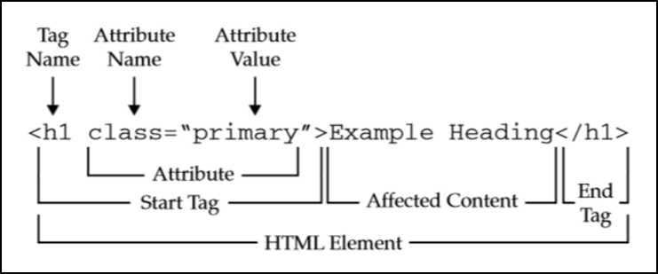

### HTML Elements (2)

Below is a list of basic HTML which are helpful for web scraping

| Tag | Description |
| --- | --- |
| `<html> </html>` | root node of html document |
| `<head> </head>` | head node of html document |
| `<title> </title>` | page title |
| `<body> </body>` | the body stores most the main page content |
| `<li> </li>` | list item |
| `<b> </b>` | bold font |
| `<p> </p>` | paragaph |
| `<img src="xxx"> </img>` | inserts image from source `xxx` |
| `<a href="xxx"> </a>` | links to destintation `xxx` |

- The Document Object Model (DOM) defines the logical structure of a document and the way it is accessed and manipulated
- HTML is structured as a tree and you should be able to characterize the path to any node or tag

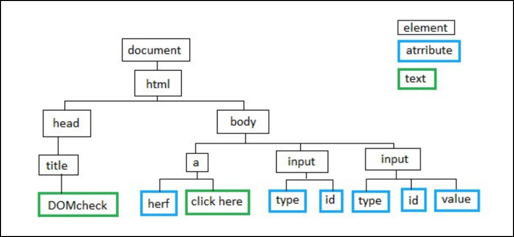

### Scraping with `rvest`: Main functions and basic workflow

- Obtain an html document from a url, a file on disk or a string containing html with `read_html()`
- Select parts of a document using css selectors: `html_nodes(doc, "table td")`
- Extract components with `html_tag()` (the name of the tag), `html_text()` (all text inside the tag), `html_attr()` (contents of a single attribute) and `html_attrs()` (all attributes) or parse tables into data frames with `html_table()`
- These functions can again be nicely stringed together using the pipe operator `%>%` - therefore we import both `rvest`and `tidyverse`

```r
library(tidyverse)
library(rvest)
```

```r
cities = "https://en.wikipedia.org/wiki/List_of_largest_cities"
paths_allowed(c(cities))
```

```
[1] TRUE
```

```r
cities %>%
  read_html() %>%
  html_table(fill = TRUE, header = TRUE) %>%
  .[[2]] %>%
  .[, c(1,2,5)] %>%
  head(10)
```

```
        City     Nation                  Population
1                                 Metropolitan area
2  Chongqing      China               17,000,000[9]
3   Shanghai      China              24,750,000[12]
4    Beijing      China              24,900,000[14]
5      Lagos    Nigeria              21,000,000[17]
6      Dhaka Bangladesh              20,000,000[19]
7     Mumbai      India                  12,771,200
8    Chengdu      China 10,376,000[citation needed]
9    Karachi   Pakistan
10 Guangzhou      China              25,000,000[29]
```

### Selecting Nodes

- If the data is not explicitly organized as a table, we need to use formatting queues to isolate data points
- `html_node()` and `html_node()` allow us to specify css selectors or xpaths to select content on a website
- Using http://selectorgadget.com/ this can be a very easy task, sometimes we need to try around a little

```r
toniErdman = "http://www.imdb.com/title/tt4048272/?ref_=nv_sr_1"

toniErdman %>%
  read_html() %>%
  html_nodes(".primary_photo+ td") %>%
  html_text()
```

```
 [1] "\n Sandra Hüller\n          "
 [2] "\n Peter Simonischek\n          "
 [3] "\n Michael Wittenborn\n          "
 [4] "\n Thomas Loibl\n          "
 [5] "\n Trystan Pütter\n          "
 [6] "\n Ingrid Bisu\n          "
 [7] "\n Hadewych Minis\n          "
 [8] "\n Lucy Russell\n          "
 [9] "\n Victoria Cocias\n          "
[10] "\n Alexandru Papadopol\n          "
[11] "\n Victoria Malektorovych\n          "
[12] "\n Ingrid Burkhard\n          "
[13] "\n Jürg Löw\n          "
[14] "\n Ruth Reinecke\n          "
[15] "\n Nicolas Wackerbarth\n          "
```

### Excursus: Cleaning strings with regular expressions

- Our results look promising so far
- However, we have already encountered artifacts that we want to get rid off
  - The population values had commas and source annotations
  - Cast list included strange non-printable artifacts
- Regular expressions (regex) are extremely useful in extracting information from any text by searching for one or more matches of a specific search pattern
- In `R` we can easily leverage the `str_replace()`, `str_replace_all()`, `str_remove()` and `str_remove_all()` funcions from `stringr` to leverage regex

https://github.com/NikoStein/ADS19/raw/master/Cheatsheets/RegexTutorialMedium.pdf

```r
toniErdman %>%
  read_html() %>%
  html_nodes(".primary_photo+ td") %>%
  html_text() %>%
  .[1] -> sample

sample
```

```
[1] "\n Sandra Hüller\n          "
```

```r
sample %>%
  str_remove_all("\\n") %>% #\n
  str_remove_all("[ \t]+$") %>% #trailing whitespace
  str_remove_all("^[ \t]") #leading whitespace
```

```
[1] "Sandra Hüller"
```

### Excursus: Cleaning strings with regular expressions (2)

- Our results look promising so far
- However, we have already encountered artifacts that we want to get rid off
  - The population values had commas and source annotations
  - Cast list included strange non-printable artifacts
- Regular expressions (regex) are extremely useful in extracting information from any text by searching for one or more matches of a specific search pattern
- In `R` we can easily leverage the `str_replace()`, `str_replace_all()`, `str_remove()` and `str_remove_all()` funcions from `stringr` to leverage regex

https://github.com/NikoStein/ADS19/raw/master/Cheatsheets/RegexTutorialMedium.pdf

```r
cities %>%
  read_html() %>%
  html_table(fill = TRUE, header = TRUE) %>%
  .[[2]] %>%
  .[3, c(1,2,4)] -> sample

sample
```

```
      City Nation     Population
3 Shanghai  China 24,256,800[11]
```

```r
sample[3] %>%
  str_remove_all(",") %>% # remove commas
  str_remove_all("\\[[\\d]*\\]") %>% # remove arbitrary number of digits enclosed by square brackets
as.numeric() #turn into number
```

```
[1] 24256800
```

### Programming Task

- Jeopardy! is a famous trivia show which has been running in the US for over thirty years
- All past episodes have been archived at http://www.j-archive.com/ and can be retrieved for practice or analysis
- Retrieve all questions for an episode of your choice
- Create a function that takes one argument - a string URL for the episode and return the final Jeopardy question

### Subpage Navigation

- Very often we have an overview site and then want to crawl all children sites
- Three step approach:
  - Retrieve the list of sub URLs using the techniques described before
  - Write a function which given an URL retrieves the relevant data from the subpage
  - Use `map` to execute the retrieval function on each of the URLs extracted in step 1

```r
overview = "http://www.j-archive.com/showseason.php?season=35"
overview %>%
  read_html() %>%
  html_nodes("td:nth-child(1) a") %>%
  html_attr("href") -> allURLs
head(allURLs,3)
```

```
[1] "http://www.j-archive.com/showgame.php?game_id=6333"
[2] "http://www.j-archive.com/showgame.php?game_id=6332"
[3] "http://www.j-archive.com/showgame.php?game_id=6330"
```

```r
getTitleOfEpisode = function(url){
  url %>%
    read_html() %>%
    html_node("h1") %>%
    html_text()}
map_chr(head(allURLs), getTitleOfEpisode)
```

```
[1] "Show #8020 - Friday, June 21, 2019"
[2] "Show #8019 - Thursday, June 20, 2019"
[3] "Show #8018 - Wednesday, June 19, 2019"
[4] "Show #8017 - Tuesday, June 18, 2019"
[5] "Show #8016 - Monday, June 17, 2019"
[6] "Show #8015 - Friday, June 14, 2019"
```

### Programming Task

- Create an rvest script that retrieves all players from a transfermarkt.de team website e.g., http://www.transfermarkt.de/fc-bayern-munchen/startseite/verein/27/saison_id/2018
- Transform the script to a function that takes the entry point as a string argument
- Retrieve all the urls from the overview site: http://www.transfermarkt.de/1-bundesliga/startseite/wettbewerb/L1/saison_id/2018
- Use a `map` function to retrieve all players from all clubs
- Extra effort: create a function to retrieve a player's relevant details (you may want to focus on age, games played, market value and primary position) and include it accordingly in your workflow